# The difference in voice pitch, loudness and reading rate between introverted and extraverted people

25. July 2022

## Introduction

- Research has shown links between extraversion and voice pitch [1],[2], loudness [3], [4] & speech rate [4], [5]
- Some research, but not extensive → first three hypotheses formed
- Also investigate whether proportion of introverts is equal to that in global population: 56.8% [6] → fourth hypothesis

## Hypotheses

*“Extraverted people have a lower pitch than introverted people.”*  
*“Extraverted people have a louder voice than introverted people.”*  
*“Extraverted people (speech) read faster than introverted people.”*  
*“The probability of someone being introverted is 56.8%.”*

## Method Questionnaire

- Age range: 20-30 years old
- Gender and native language also asked
- Francis Psychological Types Scale
- “Don’t think too long about your answers”

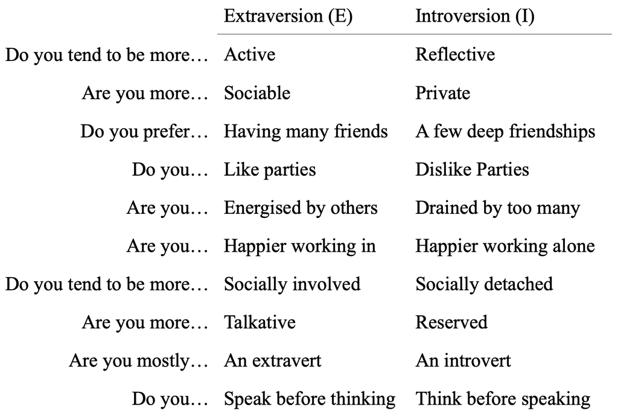

## Method Recording

- Asked to read out loud first four sentences from the fairytale *Little Red Riding Hood* in their **native language**
- Research showed that native speakers use a different pitch range when speaking foreign languages [7], [8] → Fairytales available in almost all languages
- Record at least two samples of speech in **WAV** with Audio Recorder[https://gitlab.com/axet/android-audio-recorder]

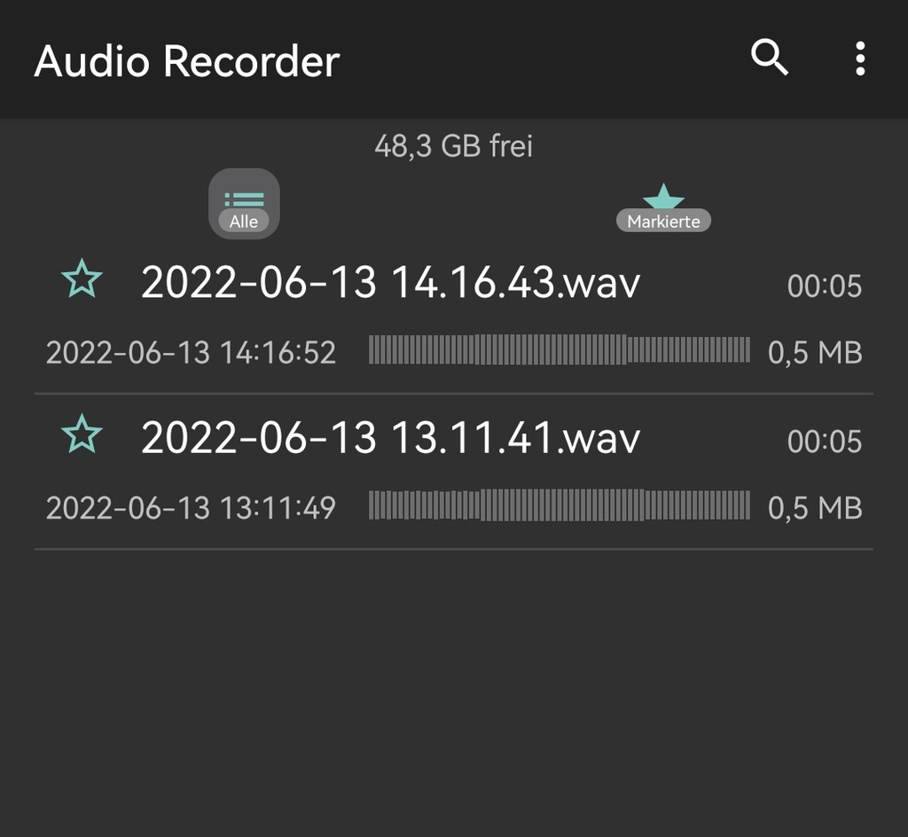

## Method Voice Pitch

- **Speaking Fundamental Frequency** (SFF) is the average fundamental frequency
  - Shows the prime tendency of the vibration frequency of the vocal folds during connected speech and correlates with the **perceived voice pitch** [9]

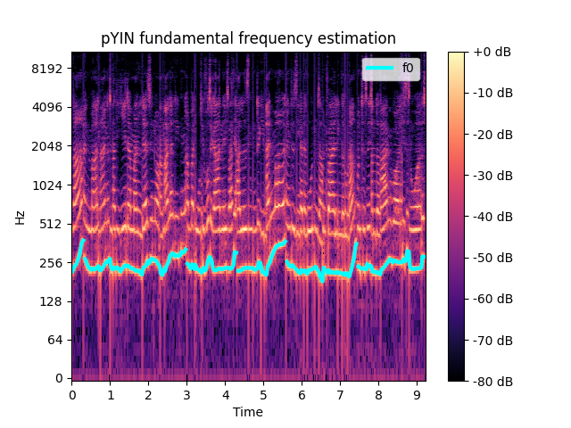

## Method Audio Analysis

[interactive chart not shown]

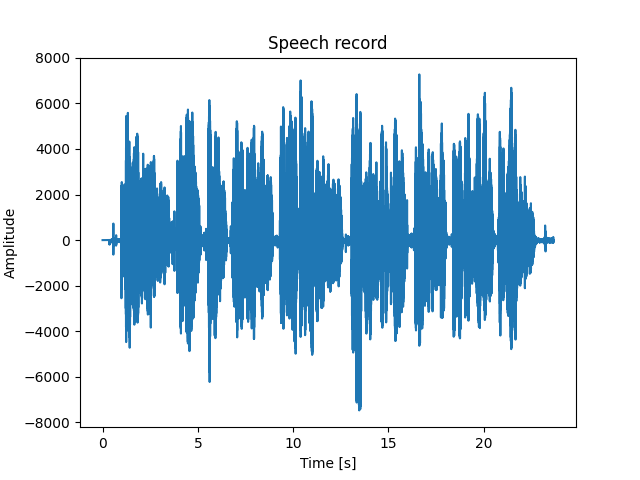

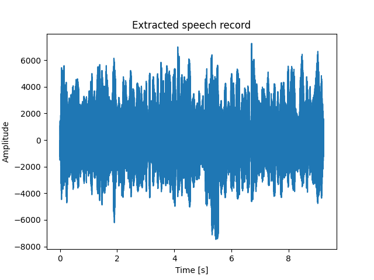

## Method Loudness

- To measure the perceived loudness of a voice we use a simple loudness meter in Python called pyloudnorm [11]
- 0 dB LUFS (Loudness Units Relative To Full Scale) is the maximum level
- The perceived loudness of the previous recording lies at about -25.51590 db LUFS

-51.48 db LUFS

[interactive chart not shown]

-13.56 db LUFS

[interactive chart not shown]

## Method Duration

- Trim each recording by removing the silence at the beginning and the end
- Compute the reading duration in seconds with Librosa
- Only native German speaker

4.62s of speech

[interactive chart not shown]

13.63s of speech

[interactive chart not shown]

## Power calculation Voice Pitch (Females)

| sig.level | power | delta | sd |
| --- | --- | --- | --- |
| 0.05 | 0.9 | 7.205149 | 19.53795 |

| alternative | n |
| --- | --- |
| one.sided | **126.6243** |

→ We would need at least 127 female participants in each group to observe significant lower voice pitches in the group of extraverts.

## Power calculation Voice Pitch (Males)

| sig.level | power | delta | sd |
| --- | --- | --- | --- |
| 0.05 | 0.9 | 6.402425 | 21.39856 |

| alternative | n |
| --- | --- |
| one.sided | **192.0084** |

## Results Participants

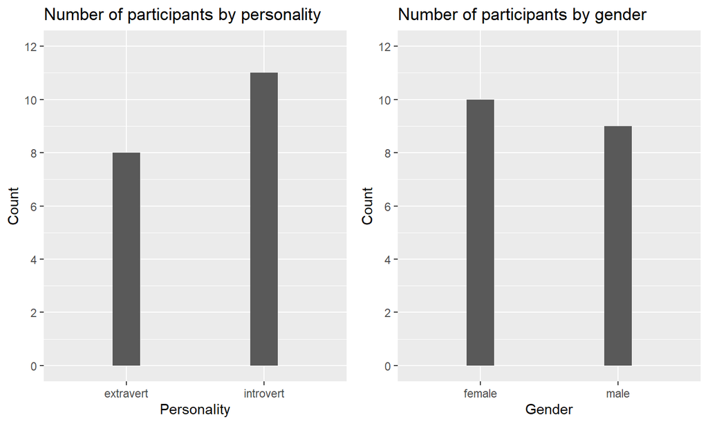

## Results Extraversion Score

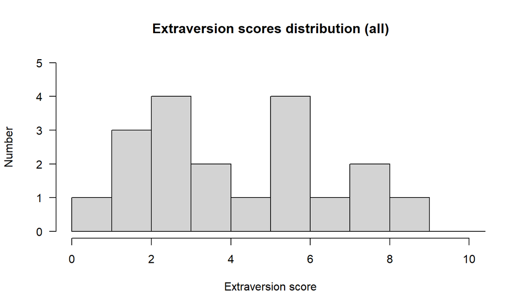

## Results Extraversion Score

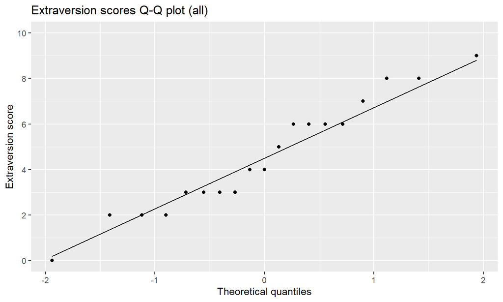

## Results Voice Pitch

Typical values for SFF are 120 Hz for men and 210 Hz for women [12]

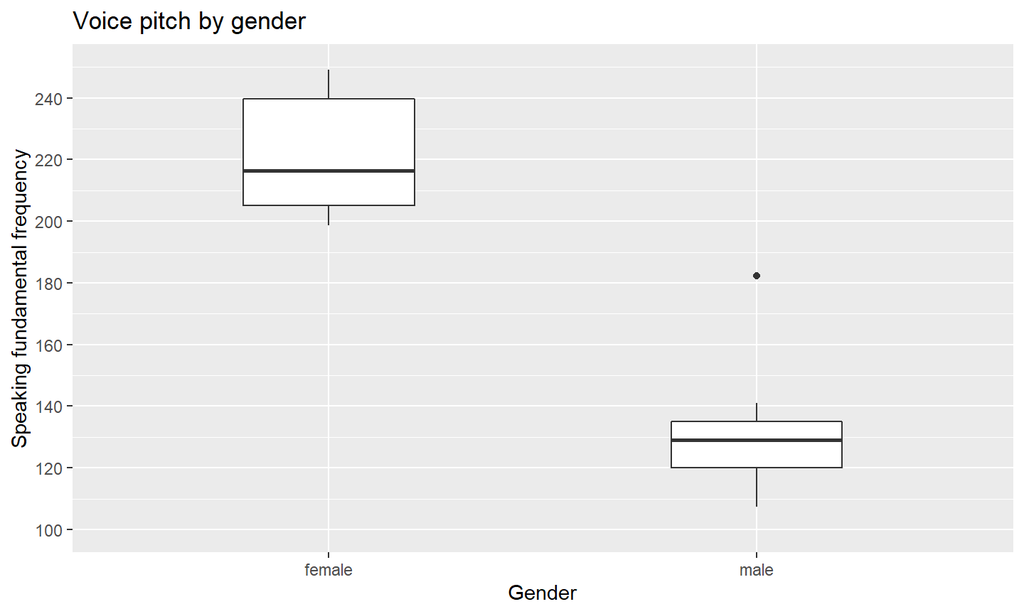

## Results Voice Pitch

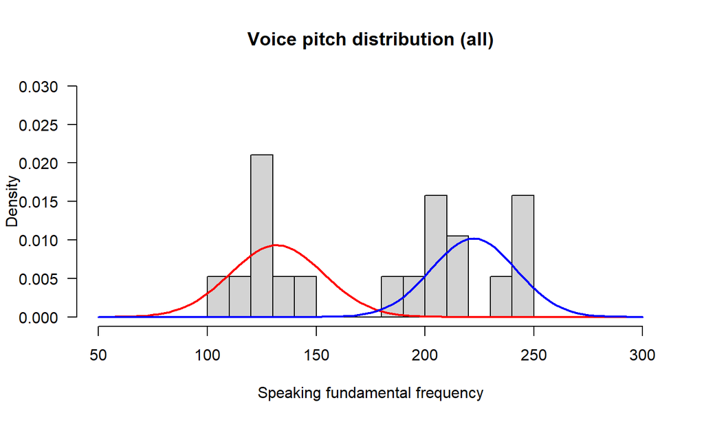

## Results Female Participants

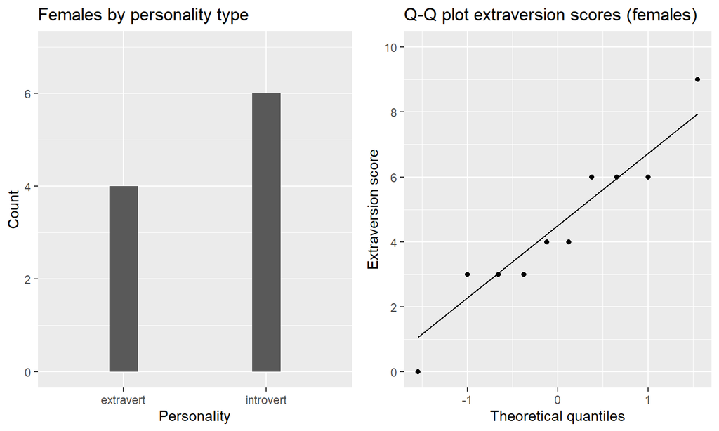

## Results Voice Pitch (Females)

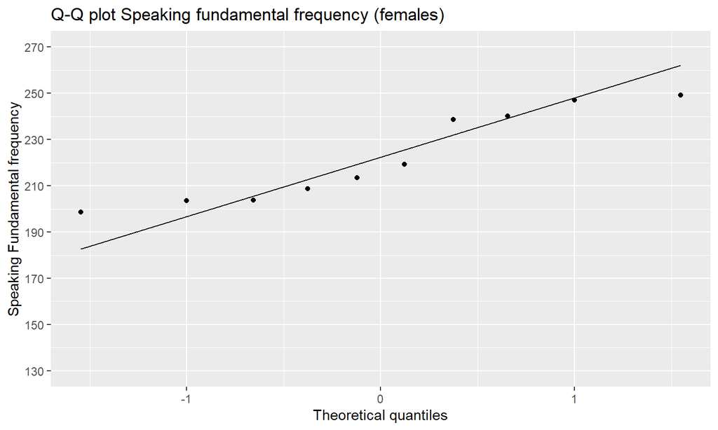

## Results Voice Pitch (Females)

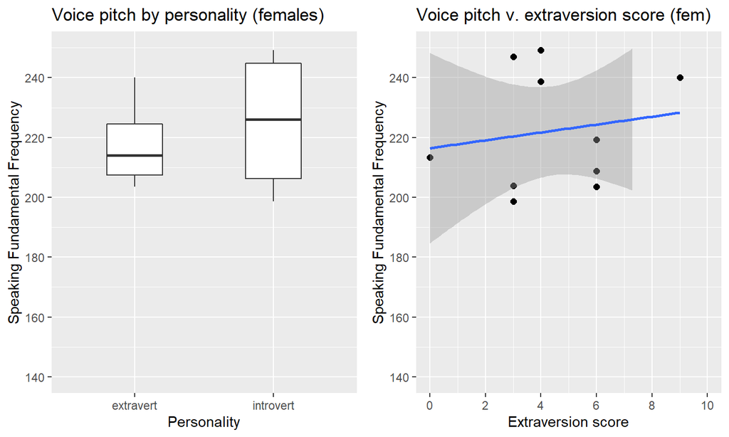

## One-sided Student’s t-test on Hypothesis 1

The data is normally distributed and the variances are equal.  
**Null hypothesis**: There is no statistically significant difference between the voice pitches of female extraverts and introverts.

| mean in group extravert | mean in group introvert |
| --- | --- |
| 217.9 | **225.1** |

| t | alpha | df | p-value |
| --- | --- | --- | --- |
| -0.5487 | 0.05 | 8 | 0.2991 |

We *do not reject* the null hypothesis as p=0.2991 > 0.05. The voice pitches of extraverted females are not significantly lower than the ones of introverted.

## Results Male Participants

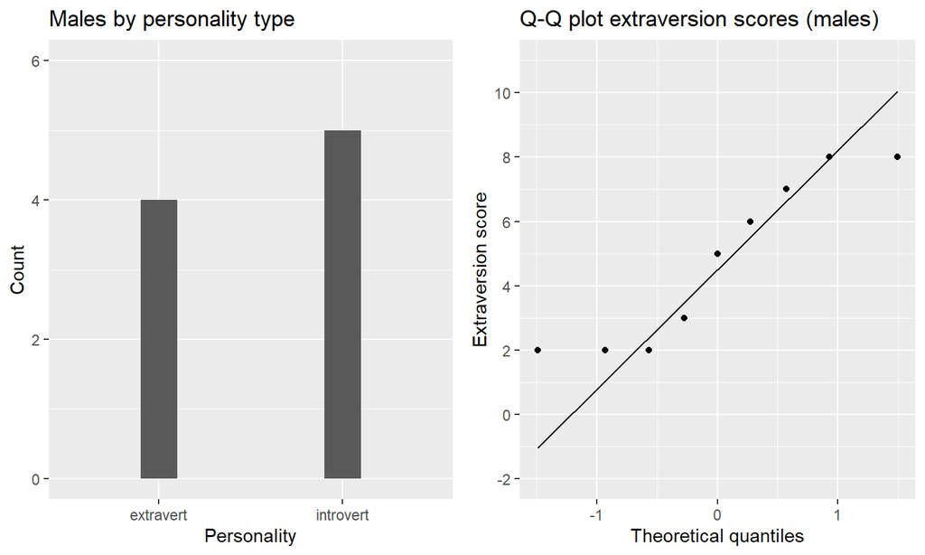

## Results Voice Pitch (Males)

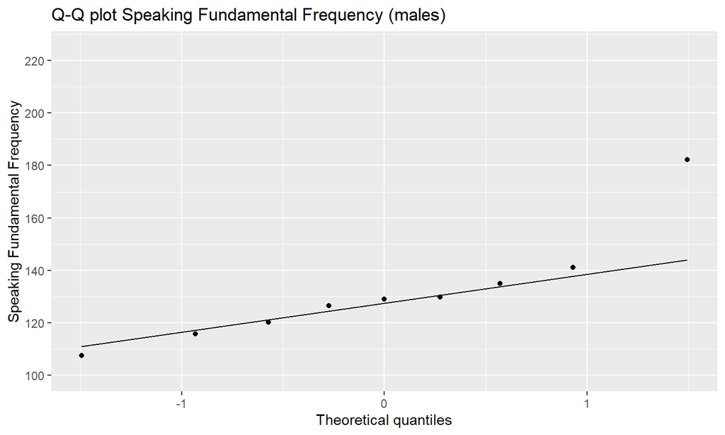

## Results Voice Pitch (Males)

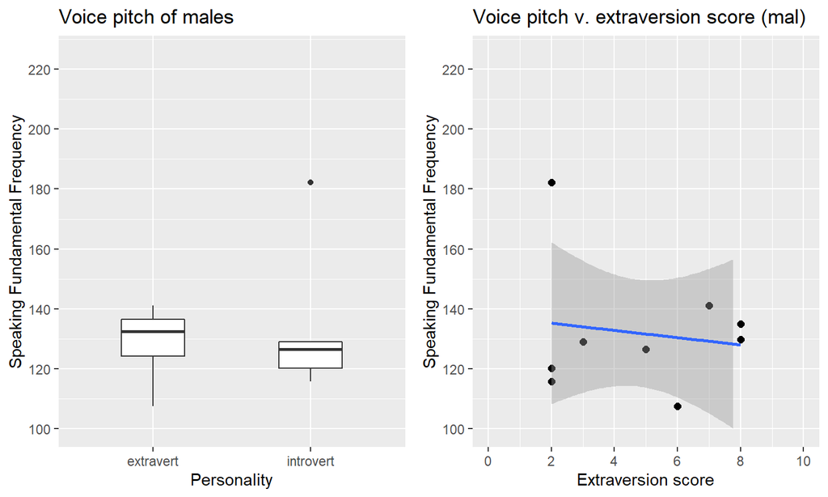

## One-sided Student’s t-test on Hypothesis 1

The data is normally distributed and the variances are equal.  
**Null hypothesis**: There is no statistically significant difference between the voice pitches of extraverted and introverted males.

| mean in group extravert | mean in group introvert |
| --- | --- |
| 128.3 | **134.7** |

| t | alpha | df | p-value |
| --- | --- | --- | --- |
| -0.4225 | 0.05 | 7 | 0.3427 |

We *do not reject* the null hypothesis as p=0.3427>0.05. The voice pitches of extraverted males are not significantly lower than the ones of introverted.

## Results Loudness

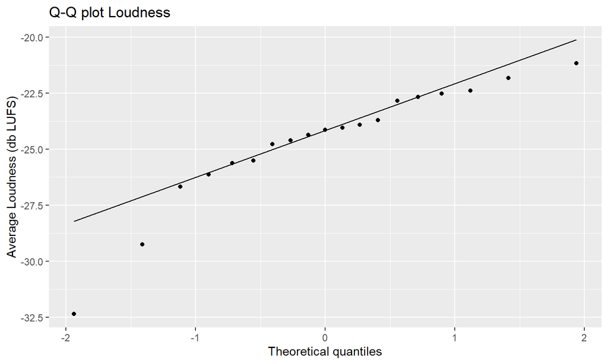

## Results Loudness

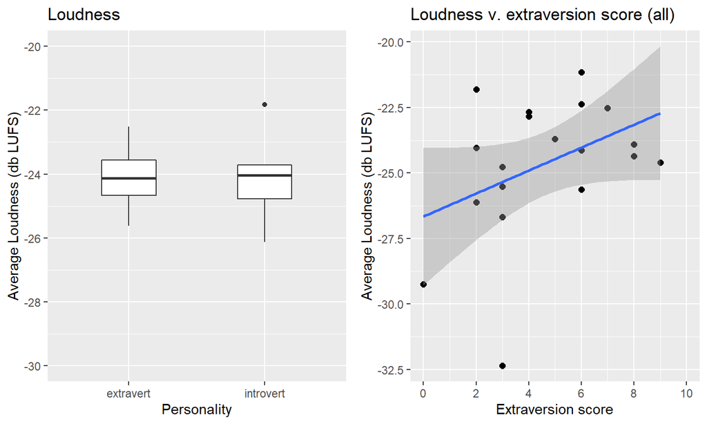

## One-sided Student’s t-test on Hypothesis 2

The data is normally distributed and the variances are equal.  
**Null hypothesis**: There is no statistically significant difference between the loudness of voice pitches of extraverted and introverted people.

| mean in group extravert | mean in group introvert |
| --- | --- |
| -23.59 | **-25.43** |

| t | alpha | df | p-value |
| --- | --- | --- | --- |
| 1.548 | 0.05 | 17 | 0.06999 |

We *do not reject* the null hypothesis as p=0.06999>0.05=alpha. The voices of extraverted people are not significantly louder than the voices of introverted people.

## Results Duration

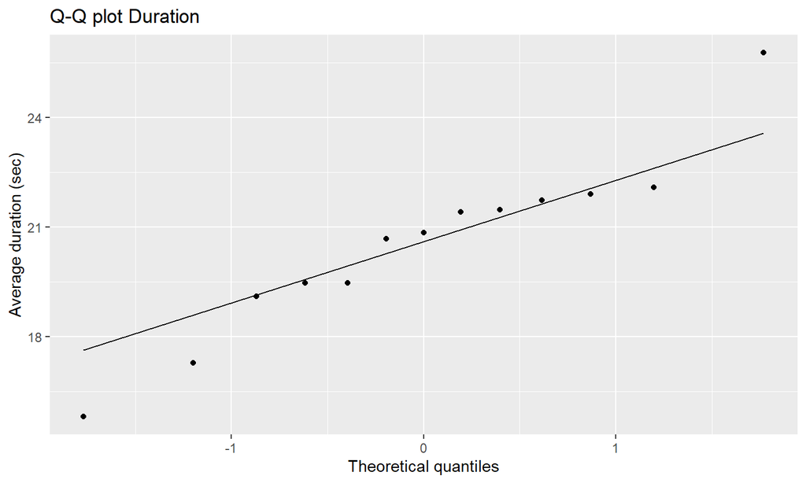

## Results

- Only German speaking participants

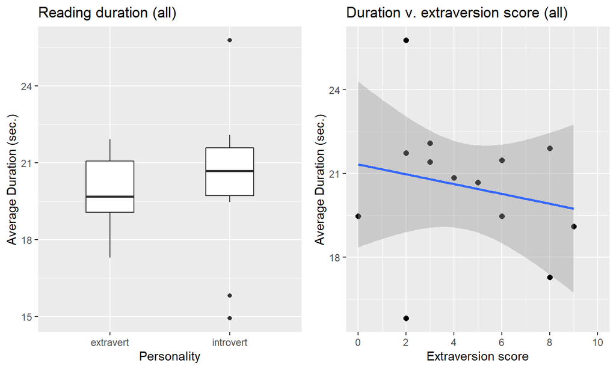

The data is not normally distributed and the variances are equal.  
**Null hypothesis**: There is no statistically significant difference between the reading duration of German extraverted and introverted people.

| median in group extravert | median in group introvert |
| --- | --- |
| 19.47 | **21.1** |

| W | alpha | p-value |
| --- | --- | --- |
| 14.5 | 0.05 | 0.2318 |

We *do not reject* the null hypothesis as p=0.2318>0.05=alpha. Extraverted people do not read significantly faster than introverted ones.

## Binomial test on Hypothesis 4

**Null hypothesis**: The probability of someone being introverted is equal to 56.8%.

| prob. in global population | prob. in research sample |
| --- | --- |
| 0.568 | **0.579** |

| alpha | p-value |
| --- | --- |
| 0.05 | 1 |

## Discussion and future research

- Small sample sizes → should be larger in future research
- Higher quality audio recording equipment + studio
- Also research on variability in voice pitch, loudness and speech rate in the future

## Questions

Thank you for your attention!  
Do you have any questions?

## References

[1] J. Stern *et al.*, “Do voices carry valid information about a speaker’s personality?” *Journal of Research in Personality*, vol. 92, 2021, doi: https://doi.org/10.1016/j.jrp.2021.104092.

[2] A. Koutsoumpis and R. E. de Vries, “What does your voice reveal about you? Trait activation of voice characteristics and their relation with personality and communication styles,” pp. 160–167, 2022, doi: https://doi.org/10.1027/1614-0001/a000362.

[3] P. Borkenau and A. Liebler, “The cross-modal consistency of personality: Inferring strangers’ traits from visual or acoustic information,” *Journal of Research in Personality*, vol. 26, no. 2, pp. 183–204, 1992, doi: 10.1016/0092-6566(92)90053-7.

[4] F. Mairesse, M. Walker, M. Mehl, and R. Moore, “Using linguistic cues for the automatic recognition of personality in conversation and text,” *J. Artif. Intell. Res. (JAIR)*, vol. 30, pp. 457–500, Sep. 2007, doi: 10.1613/jair.2349.

[5] A. J. Gill and J. Oberlander, “Taking care of the linguistic features of extraversion,” *Proceedings of the Twenty-Fourth Annual Conference of the Cognitive Science Society*, pp. 363–368, Apr. 2019, doi: 10.4324/9781315782379-99.

[6] C. Sunnyvale, “Setting the record straight on world introvert day: Introverts make great leaders too.” Jan. 2020.Available: https://www.themyersbriggs.com/en-US/Company/Press/Press/2020/January/Setting-the-Record-Straight-on-World-Introvert-Day

[7] F. Zimmerer, J. Jügler, B. Andreeva, B. Möbius, and J. Trouvain, “Too cautious to vary more? A comparison of pitch variation in native and non-native productions of french and german speakers,” May 2014.

[8] K. Järvinen, “Voice characteristics in speaking a foreign language - a study of voice in finnish and english as L1 and L2,” "PhD thesis", University of Tampere, 2017.

[9] D. R. Calvert, “Clinical measurement of speech and voice,” *The Laryngoscope*, vol. 98, no. 8, pp. 905–906, 1988, doi: https://doi.org/10.1288/00005537-198808000-00028.

[10] B. M. S. Rani, A. J. Rani, T. Ravi, and M. D. Sree, “Basic fundamental recognition of voiced unvoiced and silence region of a speech,” *International Journal of Engineering and Advanced Technology (IJEAT)*, 2014.

[11] C. J. Steinmetz and J. D. Reiss, “Pyloudnorm: A simple yet flexible loudness meter in python,” 2021.

[12] H. Traunmüller and A. Eriksson, “The frequency range of the voice fundamental in the speech of male and female adults,” vol. 2, Jan. 1995.